# R Notebook

Load in all of the data in individual data frames, calculate the years and subset them properly. Then add all of the data into big model.

```r
library(readr)
UsedCarLot <- read_csv("C:/Users/samee/Google Drive/College/STOR 455/R/Datasets/UsedCarLot.csv")
library(dplyr)
set.seed(5678)
altimaData = sample_n(subset(UsedCarLot, model=='Altima'), 50)
altimaData[,'age'] = 2018-altimaData$year
altimaData = select(altimaData, age, price, mileage, model)
jettaData = sample_n(subset(UsedCarLot, model=='Jetta'), 50)
jettaData[,'age'] = 2018-jettaData$year
jettaData = select(jettaData, age, price, mileage, model)
soulData = sample_n(subset(UsedCarLot, model=='Soul'), 50)
soulData[,'age'] = 2018-soulData$year
soulData = select(soulData, age, price, mileage, model)
accordData = sample_n(subset(UsedCarLot, model=='Accord'), 50)
accordData[,'age'] = 2018-accordData$year
accordData = select(accordData, age, price, mileage, model)
allData = rbind(altimaData, jettaData, soulData, accordData)
head(allData)
```

| age | price | mileage | model |
| --- | --- | --- | --- |
| 3 | 22.924 | 30.154 | Altima |
| 3 | 18.900 | 54.727 | Altima |
| 7 | 15.388 | 112.430 | Altima |
| 2 | 29.877 | 15.253 | Altima |
| 9 | 13.990 | 150.782 | Altima |
| 3 | 24.459 | 21.290 | Altima |

# 1

Based on this set of boxplots we see that the Honda Accord has the most variability and the highest median price. While the Altima has the second highest median price and a tighter spread. The Jetta and the Soul are very similar and we see that they both have outliers as well.

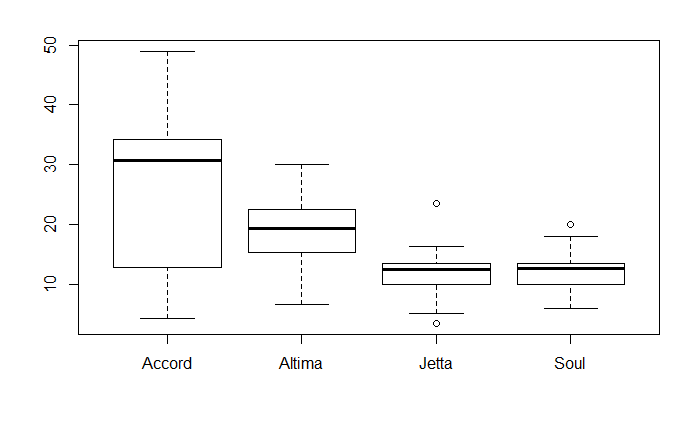

```r
boxplot(price~model, data=allData)
```

# 2

Summary statistics for the car models.

```r
tapply(allData$price, allData$model, mean)
```

```
  Accord   Altima    Jetta     Soul
27.01348 18.96352 11.91090 11.81488
```

```r
tapply(allData$price, allData$model, sd)
```

```
   Accord    Altima     Jetta      Soul
12.174240  5.426647  3.130369  2.941247
```

# 3a

Based on the summary statistics and the boxplots, I think there are significant differences in the mean prices. But Jetta and Soul look similar in means (11.91 and 11.81), but their standard deviation is slightly different.

# 3b

The only concern is that the standard deviation of the Honda Accord is quite higher than the rest of them at (12.17).

# 4

The Null hypothesis is that the mean prices of all the models are equal. While the alternate hypothesis is that some mean of one car model is not equal to some other car model. Based on the p-value of 2e-16, we can reject the null hypothesis, suggesting that there is a significant difference in means for the cars. That means the average price between one of the models we selected is significantly different from an average price of another model.

```r
anovaFull = aov(price~model, data=allData)
summary(anovaFull)
```

```
             Df Sum Sq Mean Sq F value Pr(>F)
model         3   7809    2603   53.09 <2e-16 ***
Residuals   196   9609      49
---
Signif. codes:  0 ‘***’ 0.001 ‘**’ 0.01 ‘*’ 0.05 ‘.’ 0.1 ‘ ’ 1
```

# 5a

We calculate the residuals vs. fitted and we see that the variance is scattered for each category of the car. The residuals look scattered for each model but the residuals for one seems to be more spread out. One of the models is overlapping the other one, specically the Jetta and the Soul since they have approximately the same average price.

# 5b

We calculate the qq-norm plot and the histogram of the anova residuals. The qq-norm looks approximately linear while the left tail does not look that good of a fit. However the majority of the values are on the linear line. The residuals also look approximately normal.

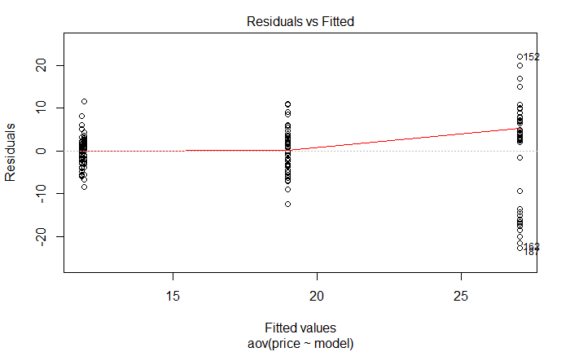

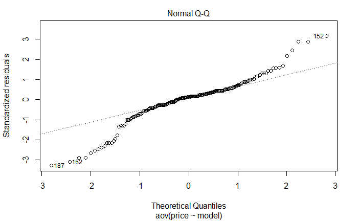

```
hat values (leverages) are all = 0.02
 and there are no factor predictors; no plot no. 5
```

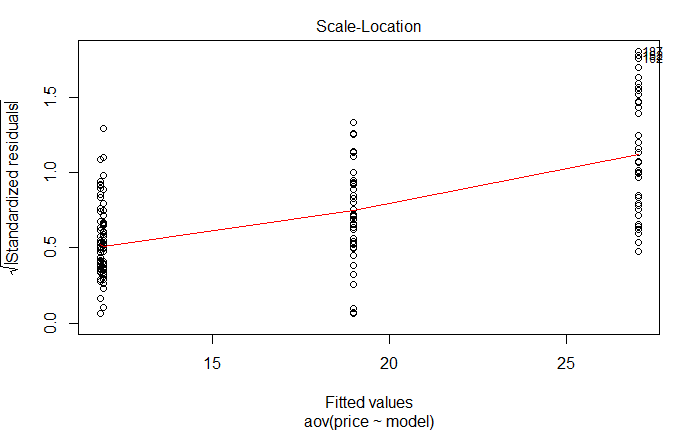

```r
plot(anovaFull)
```

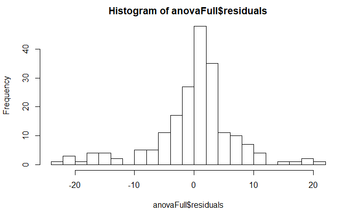

```r
hist(anovaFull$residuals, breaks=25)
```

# 6a

```r
LSD = 2.353363*sqrt(49)*sqrt((1/3)+(1/3)) #Got the t* from a table.
print(LSD)
```

```
[1] 13.45059
```

```r
pairwise.t.test(allData$price, allData$model, p.adj='none')
```

```
    Pairwise comparisons using t tests with pooled SD

data:  allData$price and allData$model

       Accord  Altima  Jetta
Altima 3.4e-08 -       -
Jetta  < 2e-16 1.1e-06 -
Soul   < 2e-16 7.8e-07 0.95

P value adjustment method: none
```

```r
qtukey(1-.05, 4, 196)
```

```
[1] 3.664521
```

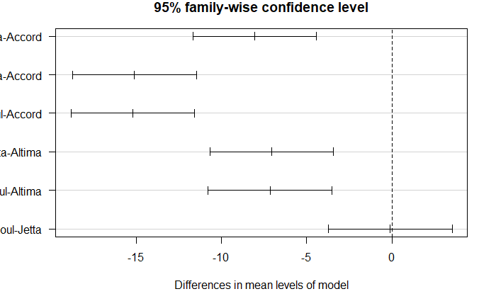

```r
HSD = TukeyHSD(anovaFull)
plot(HSD, las=1)
```

# 7

We see that the ordinary model was created using the automatic categorical variable detection. We see that the mean price is 27.0135 is the Honda Accord’s and that is also the Honda Accord’s mean price. The Jetta’s the Soul’s and the Altima’s coefficient suggests that those models would reduce the price by that amount to get to those cars respective mean prices. For example subtracting 8.05 from 27.0135 would get you to 19, which is around the mean price for Altima. Similarly we can see that the coefficient for Jetta and SOul are the same, this is because they have similar means.

```r
ordinary = lm(price~factor(model), data=allData)
summary(ordinary)
```

```
Call:
lm(formula = price ~ factor(model), data = allData)

Residuals:
     Min       1Q   Median       3Q      Max
-22.6565  -2.4134   0.9311   3.0841  21.9745

Coefficients:
                    Estimate Std. Error t value Pr(>|t|)
(Intercept)          27.0135     0.9902  27.280  < 2e-16 ***
factor(model)Altima  -8.0500     1.4004  -5.748 3.41e-08 ***
factor(model)Jetta  -15.1026     1.4004 -10.785  < 2e-16 ***
factor(model)Soul   -15.1986     1.4004 -10.853  < 2e-16 ***
---
Signif. codes:  0 ‘***’ 0.001 ‘**’ 0.01 ‘*’ 0.05 ‘.’ 0.1 ‘ ’ 1

Residual standard error: 7.002 on 196 degrees of freedom
Multiple R-squared:  0.4483,    Adjusted R-squared:  0.4399
F-statistic: 53.09 on 3 and 196 DF,  p-value: < 2.2e-16
```

# 8

For the ‘added’ model we first check if the individual predictors mileage and age are significant and we see that they are based on the p-values being less than .05. Mileage at 1.77e-11 and age at .0196.

For the ‘multiplied’ model we check if the mileage, age and the interaction between both the mileage and age are significant. Thus we see that all of the predictors are significiant for predicting the price. All p-values being less than .05. Mileage at 3.39e-12 and age at .0153 and the interaction at 5.36e-05.

Then we check the anova of the two models (individual predictors and the one with the combined interaction). And we also see that the p-value is also very low at 5.357e-.05. This suggests there is a significant variability in the model with individual predictors of mileage and age and the model with both of the predictors combined. There is a significant price difference between cars after accounting for variability. We accounted for that variability by looking at the individuals ones and then the interaction and then the difference between both and we see that there is still significant price difference based on mileage and age.

```r
added = aov(price ~ mileage+age, data=allData)
multiplied = aov(price~mileage+age + I(mileage*age), data=allData)
summary(added)
```

```
             Df Sum Sq Mean Sq F value   Pr(>F)
mileage       1   3502    3502   50.97 1.77e-11 ***
age           1    381     381    5.54   0.0196 *
Residuals   197  13536      69
---
Signif. codes:  0 ‘***’ 0.001 ‘**’ 0.01 ‘*’ 0.05 ‘.’ 0.1 ‘ ’ 1
```

```r
summary(multiplied)
```

```
                  Df Sum Sq Mean Sq F value   Pr(>F)
mileage            1   3502    3502  55.120 3.39e-12 ***
age                1    381     381   5.992   0.0153 *
I(mileage * age)   1   1084    1084  17.061 5.36e-05 ***
Residuals        196  12452      64
---
Signif. codes:  0 ‘***’ 0.001 ‘**’ 0.01 ‘*’ 0.05 ‘.’ 0.1 ‘ ’ 1
```

```r
anova(added, multiplied)
```

```
Analysis of Variance Table

Model 1: price ~ mileage + age
Model 2: price ~ mileage + age + I(mileage * age)
  Res.Df   RSS Df Sum of Sq      F    Pr(>F)
1    197 13536
2    196 12452  1    1083.9 17.061 5.357e-05 ***
---
Signif. codes:  0 ‘***’ 0.001 ‘**’ 0.01 ‘*’ 0.05 ‘.’ 0.1 ‘ ’ 1
```